# An R Markdown to examine the water chemical composition in a Transition zone at differing tide levels

kelli

2024-10-08

# Setup

### Load libaries

```r
library(ggplot2)
library(tidyverse)
library(here)
library(kableExtra)
library(ymlthis)
```

### Load **Data**

```r
chemdata <- read_csv(here("week_06", "data", "chemicaldata_maunalua.csv"))
head(chemdata)
```

```
## # A tibble: 6 × 15
##   Waypoint Zone      Lat  Long Site  Season Tide_time Temp_in Salinity Phosphate
##      <dbl> <chr>   <dbl> <dbl> <chr> <chr>  <chr>       <dbl>    <dbl>     <dbl>
## 1        1 Transi…  21.3 -158. W     SPRING Low_Day      23.8     27.7      0.54
## 2        2 Transi…  21.3 -158. W     SPRING Low_Day      23.5     30.6      0.36
## 3        3 Transi…  21.3 -158. W     SPRING Low_Day      22.6     28.4      0.5
## 4        4 Transi…  21.3 -158. W     SPRING Low_Day      24.0     32.8      0.25
## 5        5 Diffuse  21.3 -158. W     SPRING Low_Day      23.3     29.1      0.5
## 6        6 Diffuse  21.3 -158. W     SPRING Low_Day      24.0     34.0      0.13
## # ℹ 5 more variables: Silicate <dbl>, NN <dbl>, pH <dbl>, TA <dbl>,
## #   percent_sgd <dbl>
```

### Clean this data *up* for a table and a plot. Whee!

Here is how I will do it.

1. Take out NAs
2. Separate tide and time column
3. For the **table**, I will get the mean of the NN and Phosphate levels in the transition zone by the tide and site.
4. For the **plot**, I will filter so that we only have Nitrogen and Phosphate data from Wailupe.

```r
### clean data ####
clean <- chemdata %>%
filter(complete.cases(.)) %>% #filters out everything that's not complete
separate(col = Tide_time, #old column
                  into = c("Tide","Time"), #new columns
                  sep = "_")%>%
  select(c(Site, Zone, Tide, Phosphate, NN)) %>%
  filter(Zone == "Transition") #only wanna look at the transition zone
```

# Kable Table

```r
### Let's make a table of average levels of Phosphate and Nitrate & Nitrite levels by tide and site ###
summary <- clean %>%
  group_by(Tide, Site) %>%
  summarise(across(where(is.numeric), list(mean = mean), na.rm = TRUE))
kable(summary) %>%
kable_paper("hover", full_width = F)
```

| Tide | Site | Phosphate_mean | NN_mean |
| --- | --- | --- | --- |
| High | BP | 0.163000 | 1.29300 |
| High | W | 0.101875 | 0.39625 |
| Low | BP | 0.395500 | 10.46250 |
| Low | W | 0.315625 | 3.69750 |

Ok. This table? not great. I am having trouble fixing it up the way I want, like grouping the rows and renaming everything. It is currently 11:46 on Tuesday. I have full confidence I will some day see the light but I might not have time before this is due. I fully accept the consequences of my rushed and botched table. Great job Kel.

[Great Job Good Job GIF](https://tenor.com/view/great-job-good-job-awkward-wink-gif-7414352)from [Great Job GIFs](https://tenor.com/search/great+job-gifs)

# PLOT TIME BABY.

We will only plot data from Wailupe.

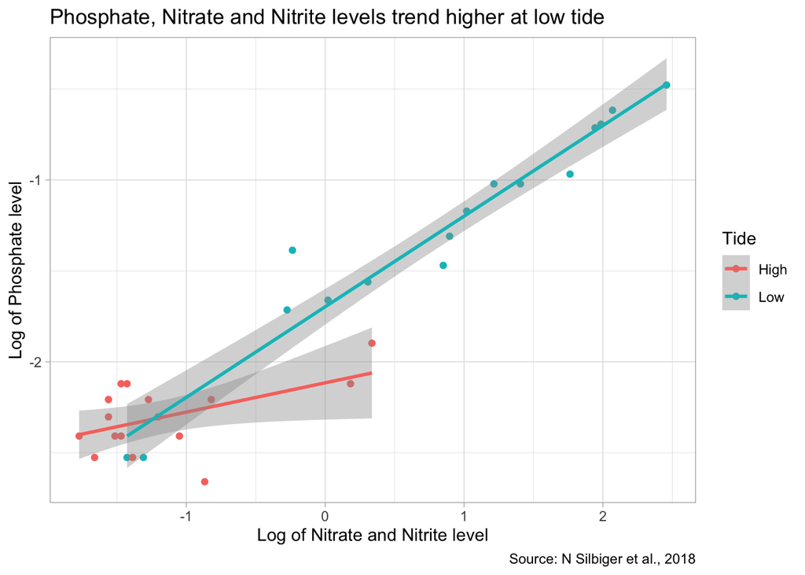

```r
plot<- clean %>%
  filter(Site == "W")
ggplot(data=plot, mapping= aes(x= log(NN),
                                   y= log(Phosphate),
                                   color = Tide)) + #colors the points by the actual raw data of that column,
  geom_point()+
  geom_smooth(method = "lm")+
  labs(title="Phosphate, Nitrate and Nitrite levels trend higher at low tide",
       x= "Log of Nitrate and Nitrite level",
       y= "Log of Phosphate level",
       color = "Tide",
       caption = "Source: N Silbiger et al., 2018") +
  theme_light()
```

# *Wow.*

We’ve done some… some work here today. I will understand if I get points knocked off of this one because both that table and that graph contribute nothing new and beautiful to the world we live in. However, it is but a step on the trail to coding transcendence.